# Prey Analysis in EAGLES

Pascal Bärtschi

2023-08-20

### Introduction

In this analysis, we will explore prey usage patterns in EAGLES using data analysis techniques. We’ll load the required libraries, read in the data, and perform relevant statistical tests to understand the differences in prey consumption between males and females. Let’s dive into the details!

First, we’ll import the necessary libraries for our analysis.

```r
suppressPackageStartupMessages({
  library("ggplot2")
  library("dplyr")
  library("ggfortify")
  library('tidyverse')
  library('GGally')
  library('MASS')
  library('readr')
})
```

### Data Loading and Exploration

```r
data <- read.csv('data/EAGLES.CSV')
# Display data structure
glimpse(data)
```

```
## Rows: 12
## Columns: 3
## $ Sex   <chr> "Female", "Female", "Female", "Female", "Female", "Female", "Mal~
## $ Prey  <chr> "Hare     ", "Squirrel ", "Vole     ", "Rat      ", "Waterbird",~
## $ Count <int> 16, 5, 24, 12, 36, 5, 7, 6, 35, 23, 23, 8
```

### Prey Usage Analysis

We’ll analyze the prey usage patterns between males and females. First, we’ll calculate the total prey counts by grouping Prey and Sex.

```r
total <- data %>%
  group_by(Prey, Sex) %>%
  summarize(count = Count)
```

Now, let’s visualize the differences in prey consumption using a grouped bar chart.

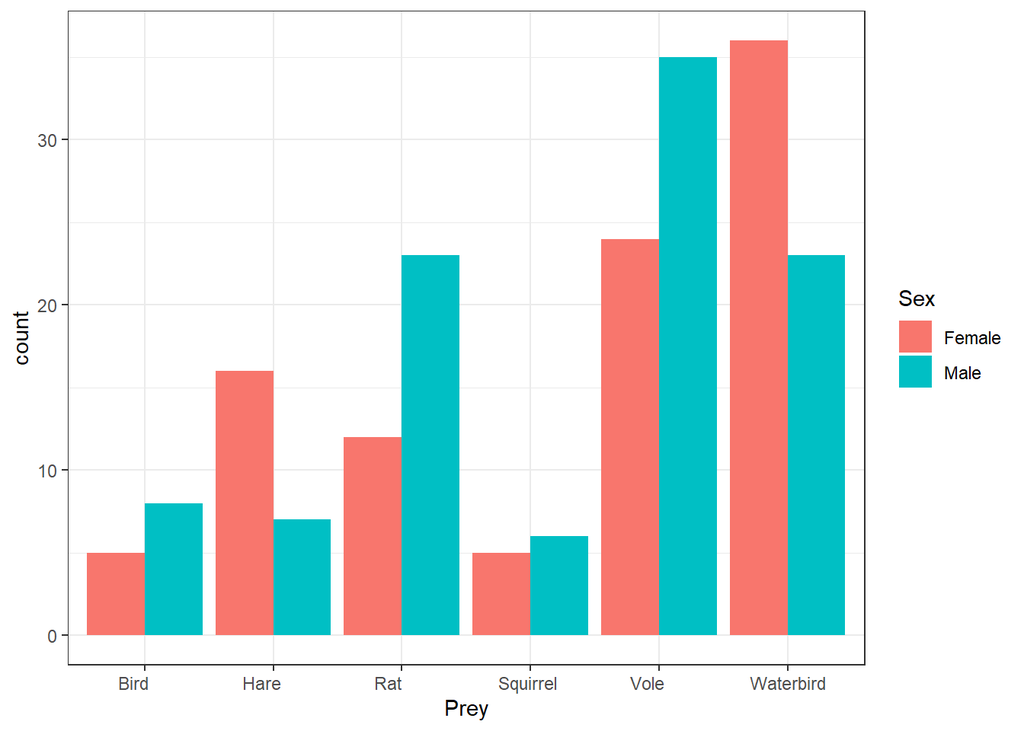

```r
ggplot(total, aes(x = Prey, y = count, fill = Sex)) +
  geom_bar(stat = 'identity', position = 'dodge') +
  theme_bw()
```

### Chi-Square Test

To determine if there are significant differences in prey consumption between males and females, we’ll perform a Chi-Square test.

```r
total.mat <- xtabs(count ~ Prey + Sex, data = total)
chisq_result <- chisq.test(total.mat)
```

[output not shown]

### Interpretation of Findings

The null hypothesis that males and females hunt for the same prey can be rejected with a p-value of 0.027 under 5 degrees of freedom. This indicates a moderate difference in prey usage patterns between males and females. For example, “Patterns of prey usage differed moderately between males and females (χ² = 12.6, df = 5, p = 0.027); for instance, females consumed many waterbirds, whereas males consumed many voles.”

### Conclusion

This analysis sheds light on the differences in prey consumption between male and female eagles. The Chi-Square test results indicate a statistically significant difference, further highlighting the distinct prey usage patterns in the two sexes.